### Summary

Various devices like FitBit measures various parameters of body movements during exercise. The question is can these measurement predict if the exercise is being done correctly? In this analysis, a control experimental data was used to model the body movements parameter to check if the exercise is done correctly or what type of mistake is being done. Random forest method was used to model. The model gave less than 1% out of sample error.

### Introduction

There has been an increased use of devices that measures the various parameters during all activities including exercise. This project is to analysis these data to see if the exercise is done correctly. First a model is built with the data from six persons doing exercise correctly and different incorrect methods. The class of exercise was modeled using the collected data from the six persons. Random forest method was used to build the model. This method showed a very low out of sample error. This model was used to predict the sample test set.

How cool it is if your Fitbit tells us if you are doing the exercise correct.

### Data load and cleanup

The data was downloaded from the website. Quick review of the data ( not shown here) several columns over 90% blank or NA data. These column were removed from the analysis. The first 5 columns were more a row indicator data and is not relevant to the analysis. These were removed as well. The final data information like:

```r
library(caret)
library(ggplot2)
setwd("~/Data Science course/ML project")
set.seed(50)
library(randomForest)

pmldata<-read.csv("pml-training.csv",header = T)

pmldata[pmldata==""]<-NA
pmldata<-pmldata[colSums(is.na(pmldata))/dim(pmldata)[1]<.1]
#remove features with unqiue values
pmldata<-pmldata[,-c(1:5)]

str(pmldata)
```

```
## 'data.frame':    19622 obs. of  55 variables:
##  $ new_window          : Factor w/ 2 levels "no","yes": 1 1 1 1 1 1 1 1 1 1 ...
##  $ num_window          : int  11 11 11 12 12 12 12 12 12 12 ...
##  $ roll_belt           : num  1.41 1.41 1.42 1.48 1.48 1.45 1.42 1.42 1.43 1.45 ...
##  $ pitch_belt          : num  8.07 8.07 8.07 8.05 8.07 8.06 8.09 8.13 8.16 8.17 ...
##  $ yaw_belt            : num  -94.4 -94.4 -94.4 -94.4 -94.4 -94.4 -94.4 -94.4 -94.4 -94.4 ...
##  $ total_accel_belt    : int  3 3 3 3 3 3 3 3 3 3 ...
##  $ gyros_belt_x        : num  0 0.02 0 0.02 0.02 0.02 0.02 0.02 0.02 0.03 ...
##  $ gyros_belt_y        : num  0 0 0 0 0.02 0 0 0 0 0 ...
##  $ gyros_belt_z        : num  -0.02 -0.02 -0.02 -0.03 -0.02 -0.02 -0.02 -0.02 -0.02 0 ...
##  $ accel_belt_x        : int  -21 -22 -20 -22 -21 -21 -22 -22 -20 -21 ...
##  $ accel_belt_y        : int  4 4 5 3 2 4 3 4 2 4 ...
##  $ accel_belt_z        : int  22 22 23 21 24 21 21 21 24 22 ...
##  $ magnet_belt_x       : int  -3 -7 -2 -6 -6 0 -4 -2 1 -3 ...
##  $ magnet_belt_y       : int  599 608 600 604 600 603 599 603 602 609 ...
```

[output cut: 41 more lines]

This data is now divided into 60% training and 40% test set.

```r
inTrain = createDataPartition(pmldata$classe, p = .6)[[1]]
training = pmldata[ inTrain,]
testing = pmldata[-inTrain,]

print(c('Training set dim ',dim(training)))
```

```
## [1] "Training set dim " "11776"             "55"
```

### Model

Choose to use random forest as a model for this set of data. Random Forest is a good accurate model. We would have used single tree classification model as well and figure out the out of sample error. For the sake of time, used only random forest method only. Note: the Caret package is very slow on my computer used the randomForest package.

The accuracy of the training set:

```r
fsmodel<-randomForest(factor(training[,55])~.,data=training[,-55],importance=TRUE,ntree=2000)

trainingpredict<-predict(fsmodel,training)
confusionMatrix(trainingpredict,training$classe)
```

```
## Confusion Matrix and Statistics
##
##           Reference
## Prediction    A    B    C    D    E
##          A 3348    0    0    0    0
##          B    0 2279    0    0    0
##          C    0    0 2054    0    0
##          D    0    0    0 1930    0
##          E    0    0    0    0 2165
##
## Overall Statistics
##
##                Accuracy : 1
##                  95% CI : (0.9997, 1)
##     No Information Rate : 0.2843
##     P-Value [Acc > NIR] : < 2.2e-16
##
##                   Kappa : 1
##  Mcnemar's Test P-Value : NA
##
## Statistics by Class:
##
##                      Class: A Class: B Class: C Class: D Class: E
## Sensitivity            1.0000   1.0000   1.0000   1.0000   1.0000
## Specificity            1.0000   1.0000   1.0000   1.0000   1.0000
## Pos Pred Value         1.0000   1.0000   1.0000   1.0000   1.0000
## Neg Pred Value         1.0000   1.0000   1.0000   1.0000   1.0000
## Prevalence             0.2843   0.1935   0.1744   0.1639   0.1838
## Detection Rate         0.2843   0.1935   0.1744   0.1639   0.1838
## Detection Prevalence   0.2843   0.1935   0.1744   0.1639   0.1838
## Balanced Accuracy      1.0000   1.0000   1.0000   1.0000   1.0000
```

This shows a high accuracy in the model. The importance of the predictors are:

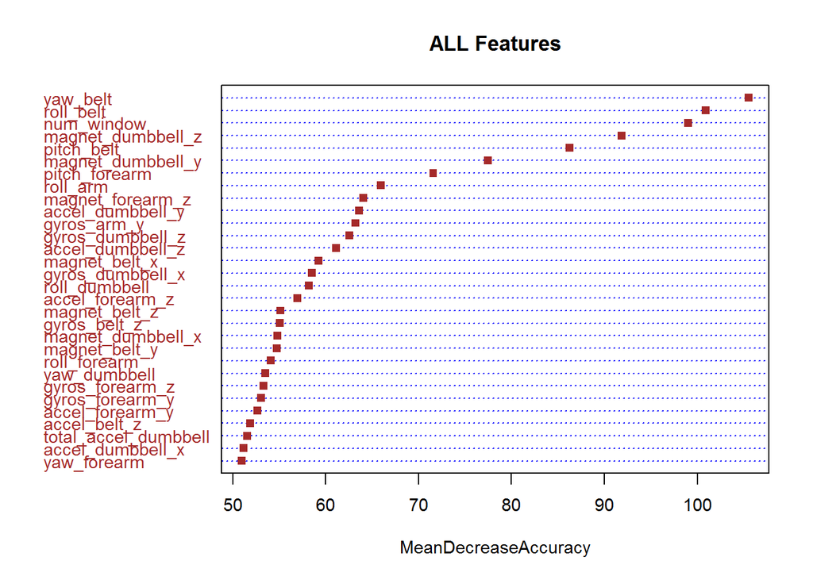

```r
varImpPlot(fsmodel,cex = 0.9, pch = 15,color = "brown", lcolor = "blue",bg="black",type=1,main="ALL Features")
```

Now let us look how well it predicts the test set:

```r
testpredict<-predict(fsmodel,testing)
confusionMatrix(testpredict,testing$classe)
```

```
## Confusion Matrix and Statistics
##
##           Reference
## Prediction    A    B    C    D    E
##          A 2232   10    0    0    0
##          B    0 1505    4    0    0
##          C    0    3 1364    6    0
##          D    0    0    0 1280    4
##          E    0    0    0    0 1438
##
## Overall Statistics
##
##                Accuracy : 0.9966
##                  95% CI : (0.995, 0.9977)
##     No Information Rate : 0.2845
##     P-Value [Acc > NIR] : < 2.2e-16
##
##                   Kappa : 0.9956
##  Mcnemar's Test P-Value : NA
##
## Statistics by Class:
##
##                      Class: A Class: B Class: C Class: D Class: E
## Sensitivity            1.0000   0.9914   0.9971   0.9953   0.9972
## Specificity            0.9982   0.9994   0.9986   0.9994   1.0000
## Pos Pred Value         0.9955   0.9973   0.9934   0.9969   1.0000
## Neg Pred Value         1.0000   0.9979   0.9994   0.9991   0.9994
## Prevalence             0.2845   0.1935   0.1744   0.1639   0.1838
## Detection Rate         0.2845   0.1918   0.1738   0.1631   0.1833
## Detection Prevalence   0.2858   0.1923   0.1750   0.1637   0.1833
## Balanced Accuracy      0.9991   0.9954   0.9978   0.9974   0.9986
```

Out of sample error is (in %):

```r
OOSErf<-1-confusionMatrix(predict(fsmodel,testing),testing$classe)$overall[1]
OOSErf*100
```

```
##  Accuracy
## 0.3441244
```

Since the out of sample error is very small, we can conclude that this is a good model.

### Cross Validation Test

```r
rf_model<-train(classe~.,data=training,method="rf",
                trControl=trainControl(method="cv",number=5),
                prox=TRUE,allowParallel=TRUE)

confusionMatrix(predict(rf_model,testing),testing$classe)
```

```
## Confusion Matrix and Statistics
##
##           Reference
## Prediction    A    B    C    D    E
##          A 2231   10    0    0    0
##          B    1 1507    1    0    0
##          C    0    1 1367    7    0
##          D    0    0    0 1279    5
##          E    0    0    0    0 1437
##
## Overall Statistics
##
##                Accuracy : 0.9968
##                  95% CI : (0.9953, 0.9979)
##     No Information Rate : 0.2845
##     P-Value [Acc > NIR] : < 2.2e-16
##
##                   Kappa : 0.996
##  Mcnemar's Test P-Value : NA
##
## Statistics by Class:
##
##                      Class: A Class: B Class: C Class: D Class: E
## Sensitivity            0.9996   0.9928   0.9993   0.9946   0.9965
## Specificity            0.9982   0.9997   0.9988   0.9992   1.0000
## Pos Pred Value         0.9955   0.9987   0.9942   0.9961   1.0000
## Neg Pred Value         0.9998   0.9983   0.9998   0.9989   0.9992
## Prevalence             0.2845   0.1935   0.1744   0.1639   0.1838
## Detection Rate         0.2843   0.1921   0.1742   0.1630   0.1832
## Detection Prevalence   0.2856   0.1923   0.1752   0.1637   0.1832
## Balanced Accuracy      0.9989   0.9962   0.9990   0.9969   0.9983
```

Out of Sample error:

```r
OOSEcv<-1-confusionMatrix(predict(rf_model,testing),testing$classe)$overall[1]
OOSEcv*100
```

```
##  Accuracy
## 0.3186337
```

Since the error is small this is also a good model. Since the difference in the error between the two method is about same, any one of the model can be used.

### Conclusion

The data set is a well behaved data set. Possible any number of models would have shown to be a good model. Random Forest model showed a less than 1% out of sample error. This model can be used to predict how well the exercise is been done by the subject.